# Exploratory Data Analysis Example

Matthew W. Van Scoyoc

Friday, January 16, 2015

# 1 R Markdown Intro

(Default text when you start a markdown document in RStudio)  
This is an R Markdown document. Markdown is a simple formatting syntax for authoring HTML, PDF, and MS Word documents. For more details on using R Markdown see http://rmarkdown.rstudio.com.

# 2 R Markdown Tips

- To start an R Markdown document select “R Markdown” from the options in the “New Document” dropdown.
- Text in the white area is normal text in the final document.
- R code is written in “chunks” (the grey areas) or in-line using “wirte code here”.
- Click on the “?” dropdown button to access markdown references. I use the “Markdown Quick Reference” in the help panel a lot.
- There are a lot of chunk options, check out to http://yihui.name/knitr/options/ when you are looking for something specific.
- For more information on R Markdown go to http://rmarkdown.rstudio.com/. To start with, check out the “Home” page, “..Authoring/Markdown Basics” and “…Authoring/R Code Chunks”.

# 3 Exploratory Data Analysis Example

In this example will use the ‘varespec’ and ‘varechem’ data sets in the vegan package to conduct exploratory data analysis on lichen communities. We will also be using modified functions from the source file ‘biostats.R’ developed by Kevin McGarigal at the University of Massachusetts. This source file has a lot of good functions for analyzing ecological data.  
(Note that the three lines above this one did not break to a new line in the document.  
You need to add 2 spaces at the end of a line if you want the next line to be a new line in the document.)

## 3.1 Summary statistics

Summary Statistics for Lichen Species Data

| names | nobs | nobs.missing | min | max | mean | median | sd | cv | skewness | kurtosis |
| --- | --- | --- | --- | --- | --- | --- | --- | --- | --- | --- |
| Callvulg | 24 | 0 | 0.00 | 24.13 | 1.88 | 0.08 | 4.99 | 265.60 | 3.93 | 18.00 |
| Empenigr | 24 | 0 | 0.13 | 16.00 | 6.33 | 5.70 | 4.77 | 75.36 | 0.43 | 2.16 |
| Rhodtome | 24 | 0 | 0.00 | 4.00 | 0.35 | 0.00 | 0.97 | 276.27 | 2.88 | 10.34 |
| Vaccmyrt | 24 | 0 | 0.00 | 18.27 | 2.11 | 0.00 | 4.82 | 228.05 | 2.51 | 8.12 |
| Vaccviti | 24 | 0 | 1.98 | 25.00 | 11.46 | 11.25 | 6.23 | 54.37 | 0.49 | 2.64 |
| Pinusylv | 24 | 0 | 0.00 | 1.20 | 0.17 | 0.10 | 0.27 | 160.02 | 2.82 | 10.31 |
| Descflex | 24 | 0 | 0.00 | 3.70 | 0.23 | 0.00 | 0.76 | 327.33 | 4.15 | 19.27 |
| Betupube | 24 | 0 | 0.00 | 0.25 | 0.01 | 0.00 | 0.05 | 421.97 | 4.50 | 21.51 |
| Vacculig | 24 | 0 | 0.00 | 8.10 | 0.63 | 0.00 | 1.70 | 268.65 | 3.74 | 16.77 |
| Diphcomp | 24 | 0 | 0.00 | 2.07 | 0.14 | 0.00 | 0.43 | 318.35 | 4.06 | 18.68 |
| Dicrsp | 24 | 0 | 0.00 | 23.43 | 1.69 | 0.00 | 5.43 | 322.04 | 3.34 | 12.83 |
| Dicrfusc | 24 | 0 | 0.00 | 37.07 | 4.73 | 0.54 | 9.10 | 192.49 | 2.51 | 8.59 |
| Dicrpoly | 24 | 0 | 0.00 | 3.00 | 0.25 | 0.02 | 0.68 | 268.63 | 3.33 | 13.12 |
| Hylosple | 24 | 0 | 0.00 | 9.97 | 0.75 | 0.00 | 2.40 | 319.38 | 3.16 | 11.58 |
| Pleuschr | 24 | 0 | 0.03 | 70.03 | 15.75 | 6.88 | 18.89 | 119.97 | 1.46 | 4.53 |
| Polypili | 24 | 0 | 0.00 | 0.25 | 0.03 | 0.00 | 0.06 | 241.69 | 2.84 | 9.96 |
| Polyjuni | 24 | 0 | 0.00 | 6.98 | 0.58 | 0.18 | 1.46 | 252.13 | 3.82 | 17.09 |
| Polycomm | 24 | 0 | 0.00 | 0.25 | 0.03 | 0.00 | 0.07 | 231.74 | 2.16 | 6.35 |
| Pohlnuta | 24 | 0 | 0.00 | 0.32 | 0.11 | 0.07 | 0.10 | 93.02 | 0.65 | 2.03 |
| Ptilcili | 24 | 0 | 0.00 | 10.00 | 0.58 | 0.03 | 2.04 | 349.61 | 4.36 | 20.57 |
| Barbhatc | 24 | 0 | 0.00 | 3.00 | 0.13 | 0.00 | 0.61 | 459.73 | 4.58 | 21.99 |
| Cladarbu | 24 | 0 | 0.17 | 39.00 | 10.63 | 7.18 | 10.60 | 99.77 | 1.29 | 3.99 |
| Cladrang | 24 | 0 | 0.87 | 59.00 | 16.20 | 10.22 | 14.91 | 92.06 | 1.24 | 4.01 |
| Cladstel | 24 | 0 | 0.00 | 84.30 | 20.28 | 3.02 | 29.32 | 144.56 | 1.26 | 3.04 |
| Cladunci | 24 | 0 | 0.05 | 23.68 | 2.34 | 0.73 | 4.97 | 211.86 | 3.58 | 15.59 |
| Cladcocc | 24 | 0 | 0.00 | 0.25 | 0.12 | 0.11 | 0.09 | 76.39 | 0.07 | 1.72 |
| Cladcorn | 24 | 0 | 0.03 | 1.42 | 0.26 | 0.22 | 0.28 | 108.54 | 3.10 | 13.34 |
| Cladgrac | 24 | 0 | 0.00 | 0.50 | 0.21 | 0.23 | 0.11 | 52.28 | 0.68 | 4.48 |
| Cladfimb | 24 | 0 | 0.00 | 0.25 | 0.16 | 0.18 | 0.08 | 48.78 | -0.60 | 2.31 |
| Cladcris | 24 | 0 | 0.02 | 1.78 | 0.31 | 0.18 | 0.43 | 137.17 | 2.33 | 7.65 |
| Cladchlo | 24 | 0 | 0.00 | 0.25 | 0.05 | 0.01 | 0.08 | 170.57 | 1.85 | 4.95 |
| Cladbotr | 24 | 0 | 0.00 | 0.25 | 0.02 | 0.00 | 0.05 | 266.61 | 3.83 | 17.27 |
| Cladamau | 24 | 0 | 0.00 | 0.08 | 0.01 | 0.00 | 0.02 | 307.15 | 3.34 | 13.63 |
| Cladsp | 24 | 0 | 0.00 | 0.25 | 0.02 | 0.00 | 0.05 | 239.50 | 3.78 | 17.06 |
| Cetreric | 24 | 0 | 0.00 | 0.78 | 0.15 | 0.05 | 0.21 | 139.40 | 1.83 | 5.78 |
| Cetrisla | 24 | 0 | 0.00 | 0.67 | 0.08 | 0.02 | 0.16 | 183.32 | 2.51 | 9.50 |
| Flavniva | 24 | 0 | 0.00 | 10.03 | 0.49 | 0.00 | 2.04 | 412.56 | 4.55 | 21.79 |
| Nepharct | 24 | 0 | 0.00 | 4.87 | 0.22 | 0.00 | 0.99 | 452.56 | 4.57 | 21.93 |
| Stersp | 24 | 0 | 0.00 | 10.28 | 0.73 | 0.06 | 2.08 | 284.87 | 4.28 | 20.19 |
| Peltapht | 24 | 0 | 0.00 | 0.33 | 0.03 | 0.00 | 0.08 | 261.68 | 2.85 | 9.83 |
| Icmaeric | 24 | 0 | 0.00 | 0.10 | 0.01 | 0.00 | 0.02 | 270.90 | 2.81 | 9.80 |
| Cladcerv | 24 | 0 | 0.00 | 0.05 | 0.00 | 0.00 | 0.01 | 291.08 | 2.89 | 10.33 |
| Claddefo | 24 | 0 | 0.00 | 1.97 | 0.43 | 0.25 | 0.51 | 119.52 | 1.82 | 5.40 |
| Cladphyl | 24 | 0 | 0.00 | 0.25 | 0.03 | 0.00 | 0.08 | 252.81 | 2.21 | 5.97 |

Summary Statistics for Soil Characteristics

| names | nobs | nobs.missing | min | max | mean | median | sd | cv | skewness | kurtosis |
| --- | --- | --- | --- | --- | --- | --- | --- | --- | --- | --- |
| N | 24 | 0 | 13.40 | 33.1 | 22.38 | 22.05 | 5.53 | 24.70 | 0.24 | 2.18 |
| P | 24 | 0 | 22.70 | 73.5 | 45.08 | 41.50 | 14.95 | 33.16 | 0.24 | 1.91 |
| K | 24 | 0 | 43.60 | 313.8 | 162.93 | 166.60 | 64.84 | 39.80 | 0.15 | 2.83 |
| Ca | 24 | 0 | 188.50 | 1169.7 | 569.66 | 518.50 | 243.58 | 42.76 | 0.45 | 2.93 |
| Mg | 24 | 0 | 25.70 | 209.1 | 87.46 | 75.05 | 41.01 | 46.89 | 1.09 | 4.37 |
| S | 24 | 0 | 14.90 | 60.2 | 37.19 | 36.25 | 11.67 | 31.37 | 0.17 | 2.42 |
| Al | 24 | 0 | 12.10 | 435.1 | 142.47 | 106.80 | 122.32 | 85.85 | 0.80 | 2.54 |
| Fe | 24 | 0 | 2.30 | 204.4 | 49.61 | 27.80 | 60.45 | 121.84 | 1.42 | 4.03 |
| Mn | 24 | 0 | 10.10 | 132.0 | 49.33 | 36.55 | 33.91 | 68.74 | 1.20 | 3.37 |
| Zn | 24 | 0 | 2.60 | 16.8 | 7.60 | 8.10 | 2.98 | 39.28 | 0.85 | 5.02 |
| Mo | 24 | 0 | 0.05 | 1.1 | 0.40 | 0.30 | 0.24 | 60.63 | 1.11 | 4.38 |
| Baresoil | 24 | 0 | 0.01 | 56.9 | 22.95 | 21.25 | 16.44 | 71.63 | 0.59 | 2.44 |
| Humdepth | 24 | 0 | 1.00 | 3.8 | 2.20 | 2.20 | 0.66 | 30.21 | 0.19 | 2.96 |
| pH | 24 | 0 | 2.70 | 3.6 | 2.93 | 2.90 | 0.21 | 7.30 | 1.40 | 5.11 |

## 3.2 Figures of each variable

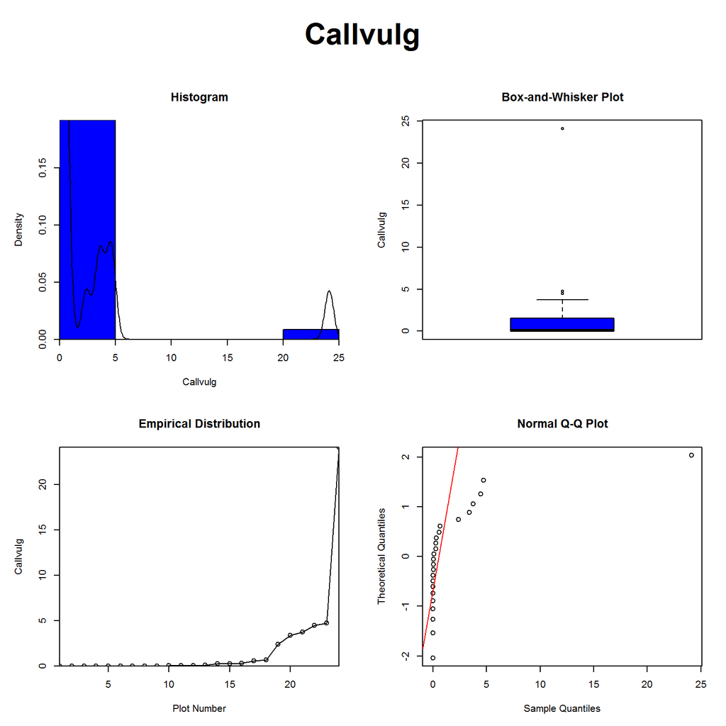

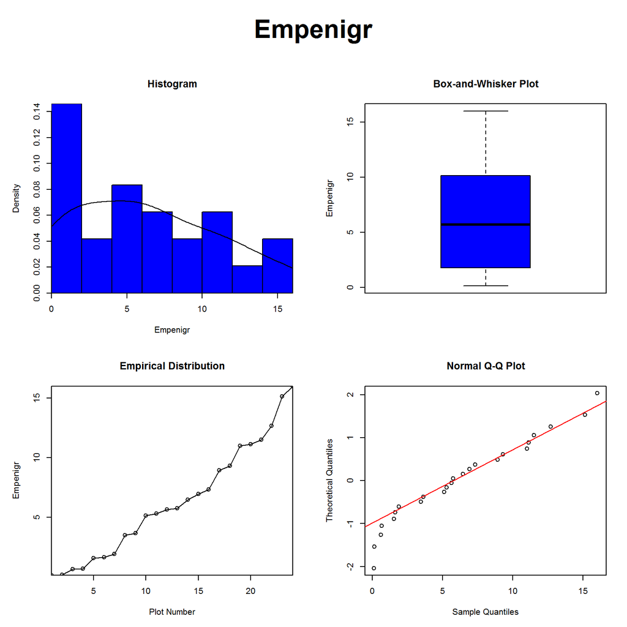

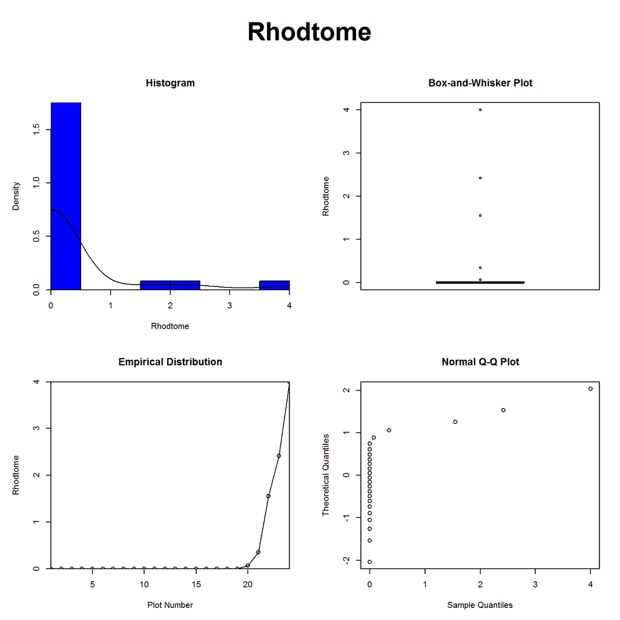

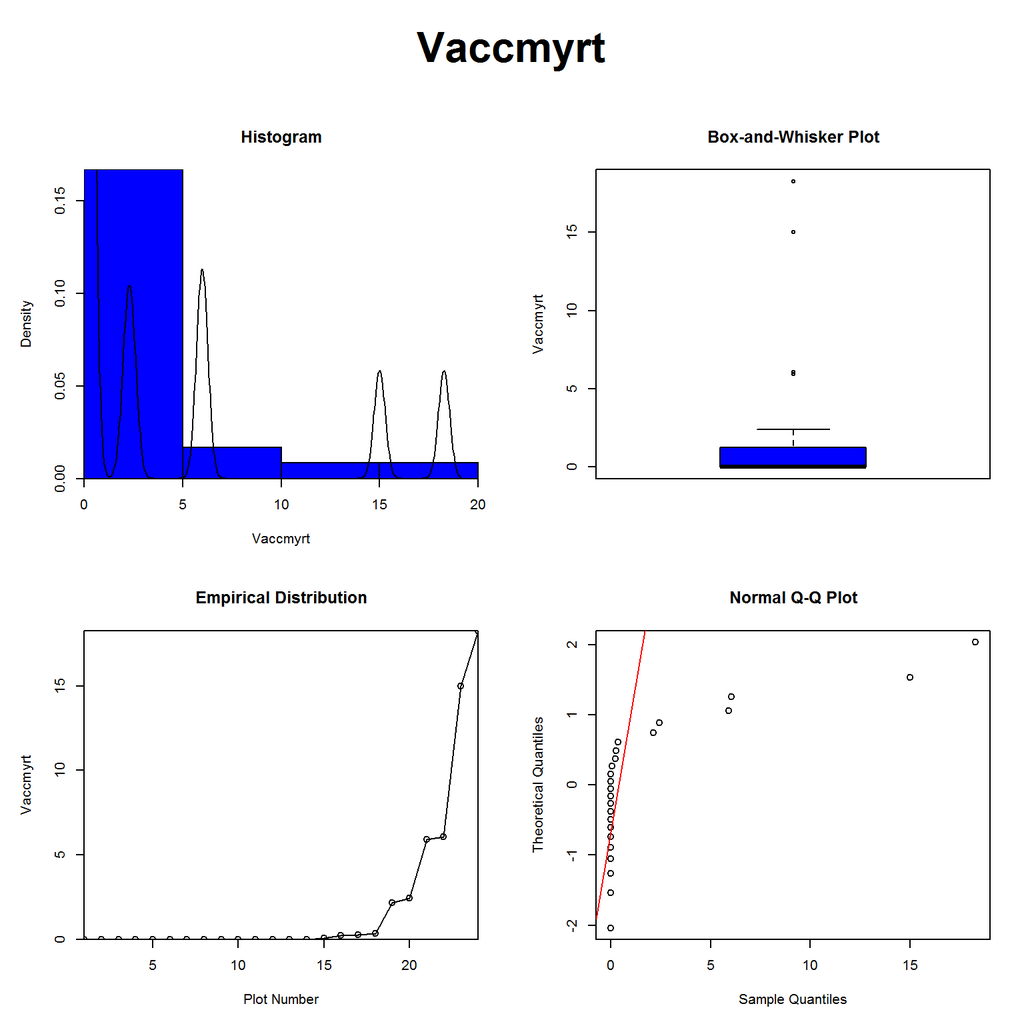

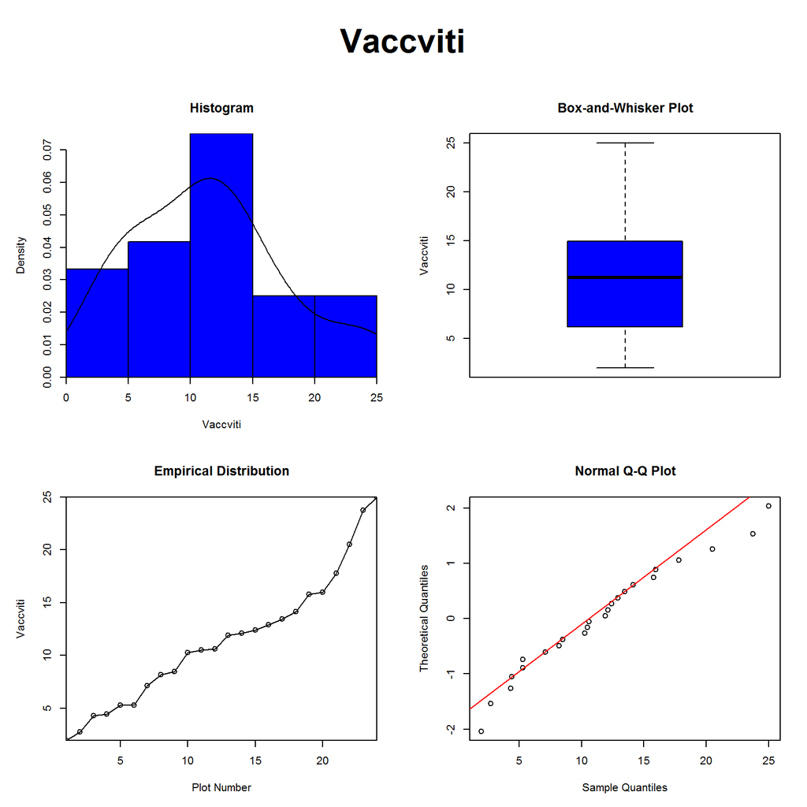

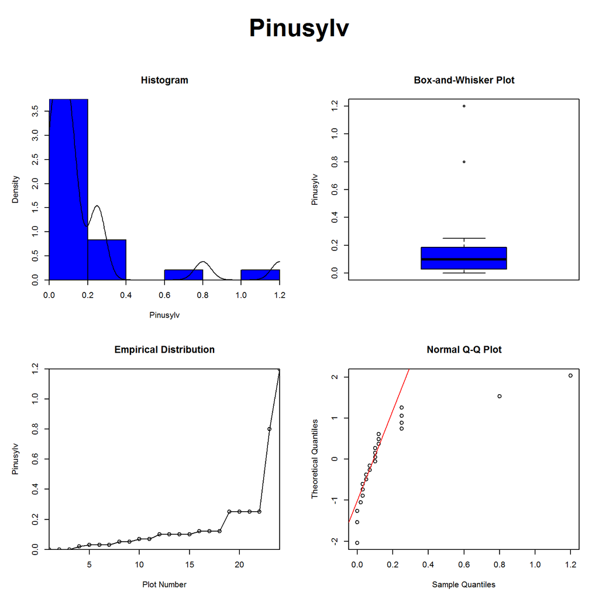

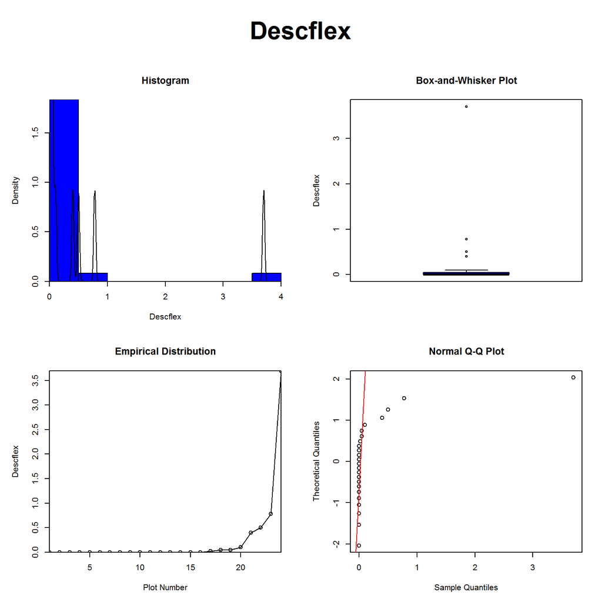

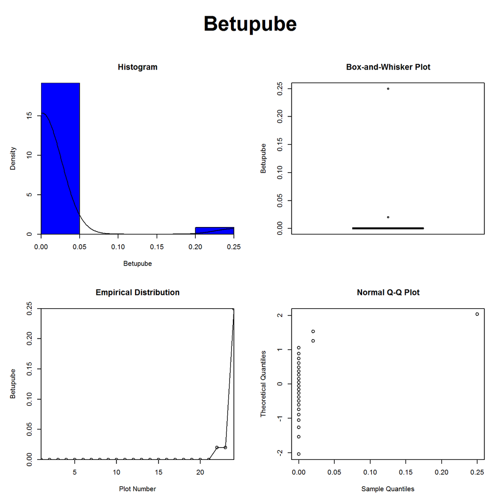

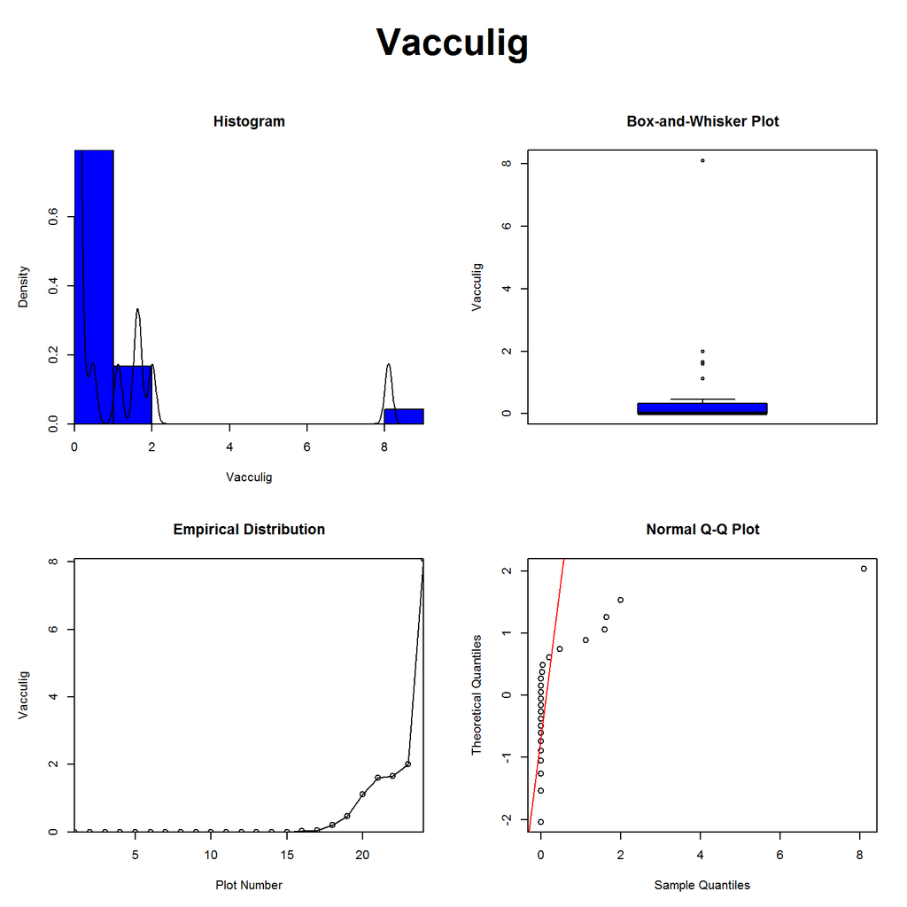

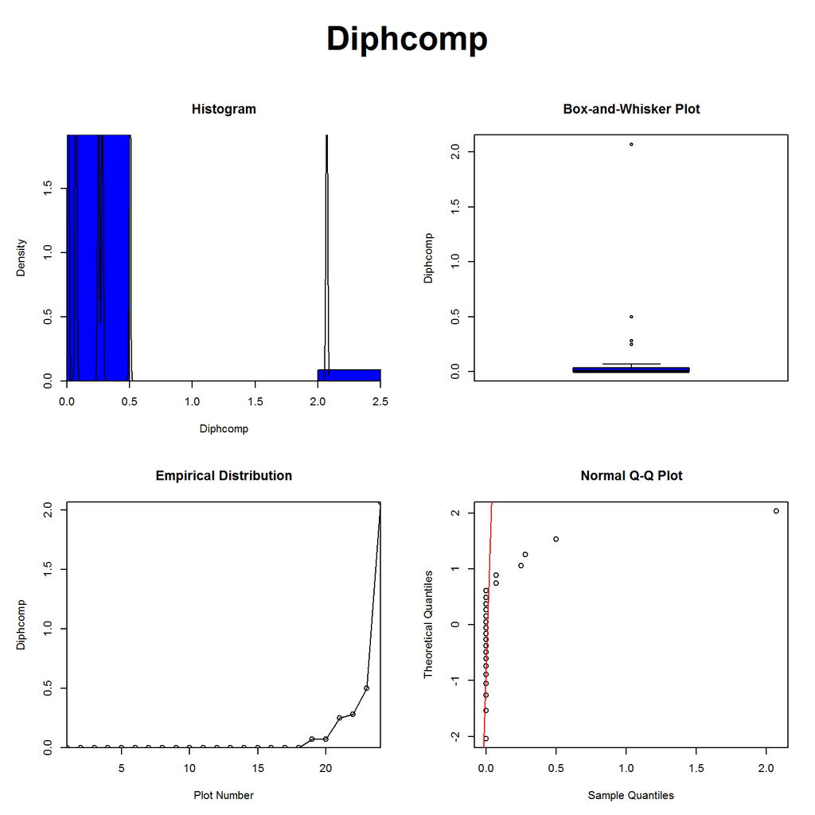

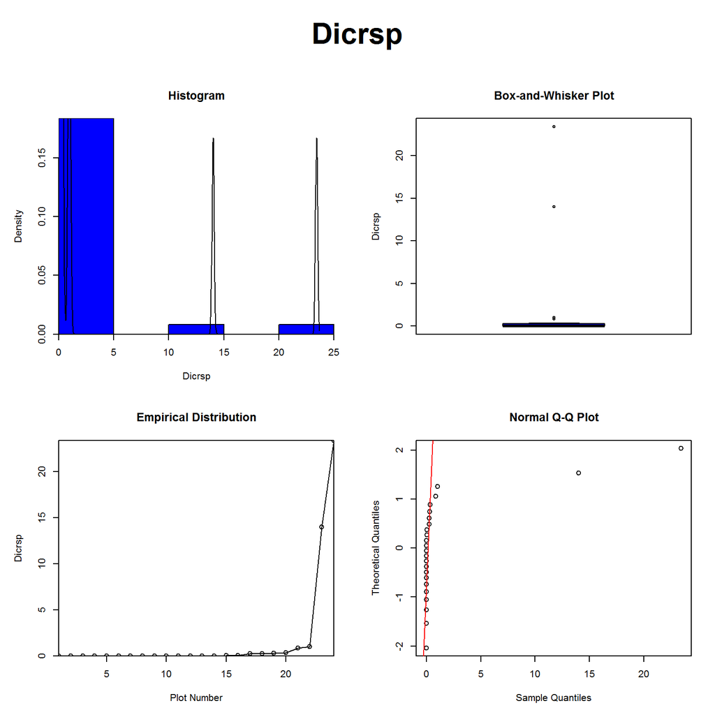

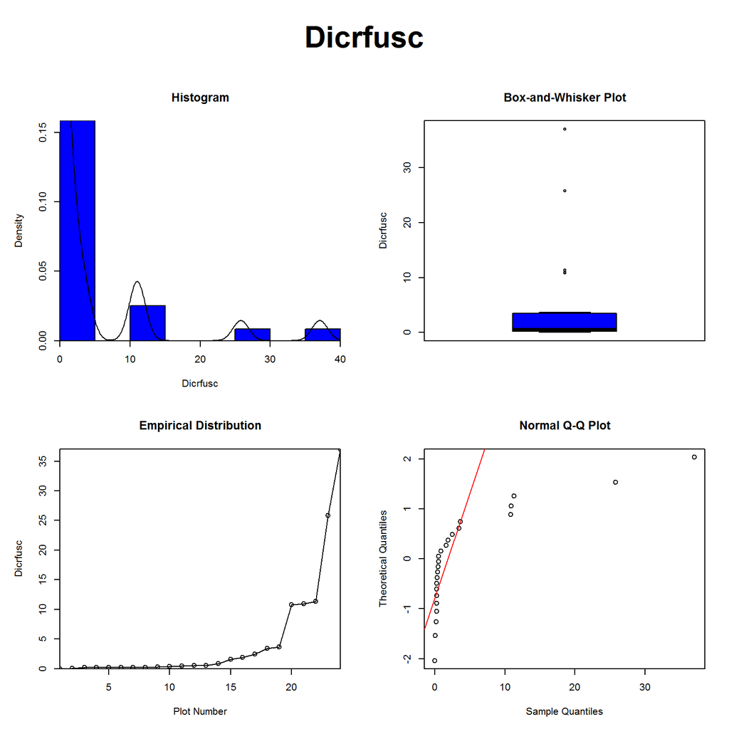

[47 more figures not shown]

All analyses were performed using R (ver. 3.1.2; R Core Team 2014), the package moments (ver. 0.14; Komsta & Novomestky 2015) for summary statistics, the source file `biostats.R` developed by Kevin McGarigal for graphical diagnostics, and the package knitr (ver 1.8; Xie 2014) for reproducible research.

This report was automatically generated with R Markdown v2. The R session information (including the OS info, R version, and all packages used):

[session information not shown]

```
## [1] "2015-01-16 09:30:45 MST"
```